# Project 3

For this project, several csv files contain related information about Texas legislators and their comittees were imported into a remote OracleDB.

## Importing Dataframes

The first step is to initialize the required packages for this project

```r
source("../01_Data/Packages.R", echo=TRUE)
```

```
##
## > require("bitops")
```

```
##
## > require("ggplot2")
```

```
##
## > require("gplots")
```

```
##
## > require("plyr")
```

```
##
## > require("grid")
```

```
##
## > require("RCurl")
```

```
##
## > require("reshape2")
```

```
##
## > require("tidyr")
```

```
##
## > require("dplyr")
```

```
##
## > require("jsonlite")
```

Next, we will build our dataframe. We grab the data from the Oracle Database with a SQL query. The following dataframe shown is the head of the whole dataframe.

```r
source("../01_Data/Dataframe.R", echo=TRUE)
```

```
##
## > dfL <- data.frame(fromJSON(getURL(URLencode("129.152.144.84:5001/rest/native/?query=\"select * from LEGISLATOR\""),
## +     httpheader = c(DB = "jdbc ..." ... [TRUNCATED]
##
## > head(dfL)
##      LEG_ID        FULL_NAME FIRST_NAME LAST_NAME SUFFIXES ACTIVE STATE
## 1 TXL000493     Matt Rinaldi       Matt   Rinaldi     null   True    tx
## 2 TXL000269 Roland Gutierrez     Roland Gutierrez     null   True    tx
## 3 TXL000475     Celia Israel      Celia    Israel     null   True    tx
## 4 TXL000445       Jeff Leach       Jeff     Leach     null   True    tx
## 5 TXL000494   Gary VanDeaver       Gary VanDeaver     null   True    tx
## 6 TXL000462      Ron Simmons        Ron   Simmons     null   True    tx
##        PARTY SERIALID
## 1 Republican      128
## 2 Democratic      129
## 3 Democratic      130
## 4 Republican      131
## 5 Republican      132
## 6 Republican      133
##
## > dfR <- data.frame(fromJSON(getURL(URLencode("129.152.144.84:5001/rest/native/?query=\"select * from LEGISLATOR_ROLE\""),
## +     httpheader = c(DB =  .... [TRUNCATED]
##
## > head(dfR)
##      LEG_ID             TYPE TERM DISTRICT CHAMBER PARTY COMMITTEE_ID
## 1 TXL000197 committee member   82     null   upper  null    TXC000039
## 2 TXL000197 committee member   82     null   upper  null    TXC000040
## 3 TXL000197 committee member   82     null   upper  null    TXC000138
## 4 TXL000197 committee member   82     null   upper  null    TXC000041
## 5 TXL000197 committee member   82     null   upper  null         null
## 6 TXL000197 committee member   82     null   upper  null    TXC000140
##                       COMMITTEE SERIALID
## 1           Business & Commerce       97
## 2 Committee of the Whole Senate       98
## 3   Cruise Industry Development       99
## 4          Economic Development      100
## 5          Economic Development      101
## 6  Economic Development, Select      102
```

## Data Wrangling

We now use the data wrangling to filter and join dataframes together for analysis.

The following are the datasets wrangled for analysis purposes using the tables Legislator and Legislator_Roles.

```r
source("../02_Data_Wrangling/Wrangling.R", echo=TRUE)
```

```
##
## > g1 <- inner_join(dfL, dfR, by = "SERIALID") %>% select(COMMITTEE_ID,
## +     COMMITTEE, FULL_NAME, CHAMBER) %>% group_by(COMMITTEE_ID,
## +     COMMITT .... [TRUNCATED]
##
## > g2 <- inner_join(dfL, dfR, by = "SERIALID") %>% select(COMMITTEE_ID,
## +     ACTIVE) %>% group_by(COMMITTEE_ID, ACTIVE) %>% filter(COMMITTEE_ID !=
## + .... [TRUNCATED]
##
## > g3 <- inner_join(dfL, dfR, by = "SERIALID") %>% select(FULL_NAME,
## +     TERM, PARTY.x, TYPE) %>% filter(TYPE == "member", PARTY.x !=
## +     "null")
```

The first dataset filters the joined table see the relationship between the committee and the names of the legislators in it.

The second dataset filters down the joined table to view the number of active legislators and inactive legislators in each committtee.

The last dataset examines the name and term of selected legislators as well as their party affiliation.

## Visualization

Finally, we can visualize the filtered datasets from the step from above.

```r
source("../03_Visualizations/Visualization.R", echo=TRUE)
```

```
##
## > g1 %>% ggplot(aes(x = FULL_NAME, y = COMMITTEE_ID,
## +     color = CHAMBER)) + geom_point() + ggtitle("Committees and Members") +
## +     theme(plot.t .... [TRUNCATED]
```

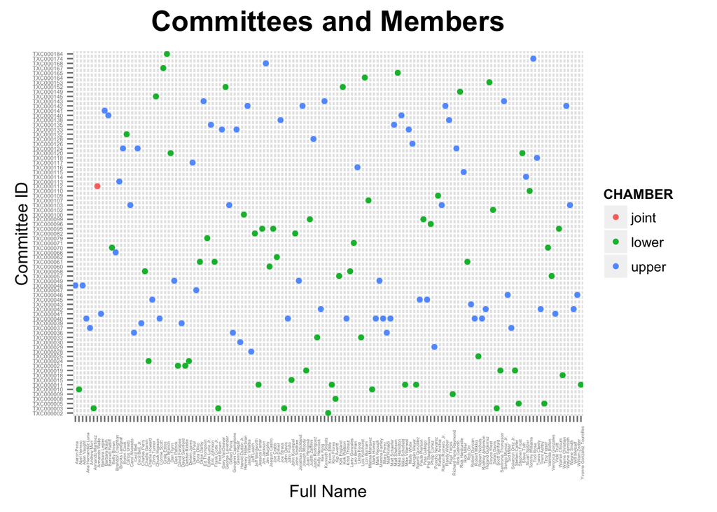

```
##
## > g2 %>% ggplot(aes(x = COMMITTEE_ID, y = n, color = ACTIVE)) +
## +     geom_point() + ggtitle("Number of Actives and Inactives in Each Committee") +
##  .... [TRUNCATED]
```

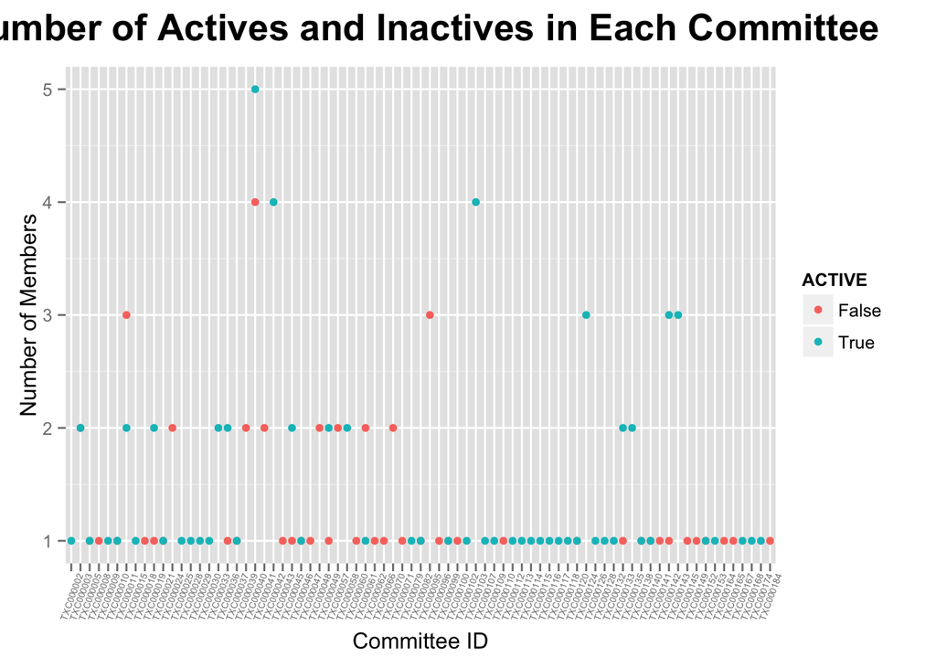

```
##
## > g3 %>% ggplot(aes(x = FULL_NAME, y = TERM, color = PARTY.x)) +
## +     geom_point() + ggtitle("Term and Party of Non-Committee Members") +
## +     the .... [TRUNCATED]
```

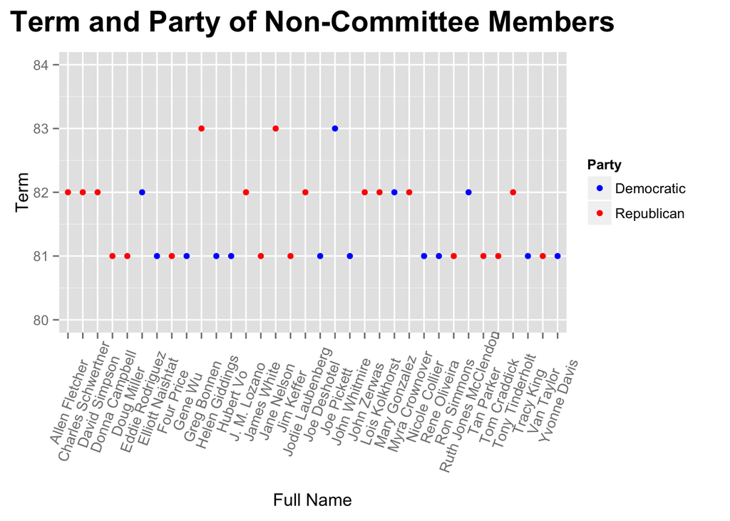

The last visualization provides a segment of the legislator’s party and the term they served.

Finally, the following are visualization of categorical and measure columns:

```r
source("../03_Visualizations/Categorical.R", echo=FALSE)
```

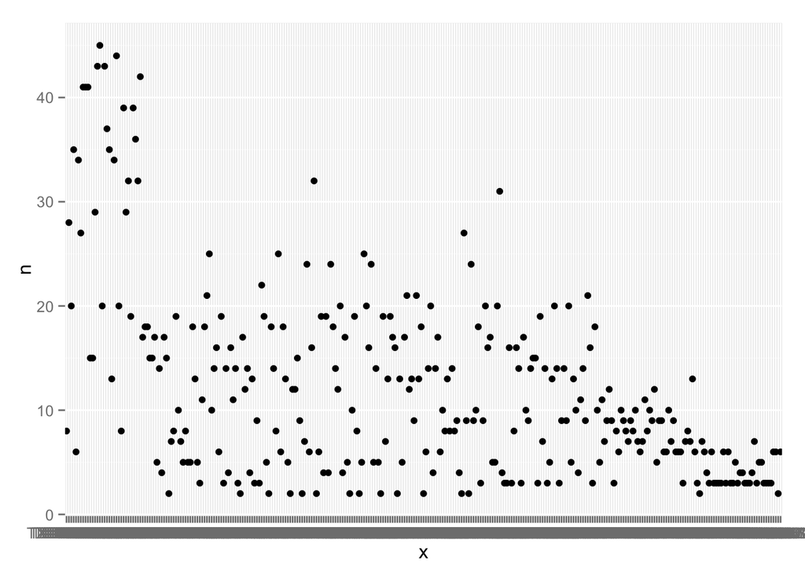

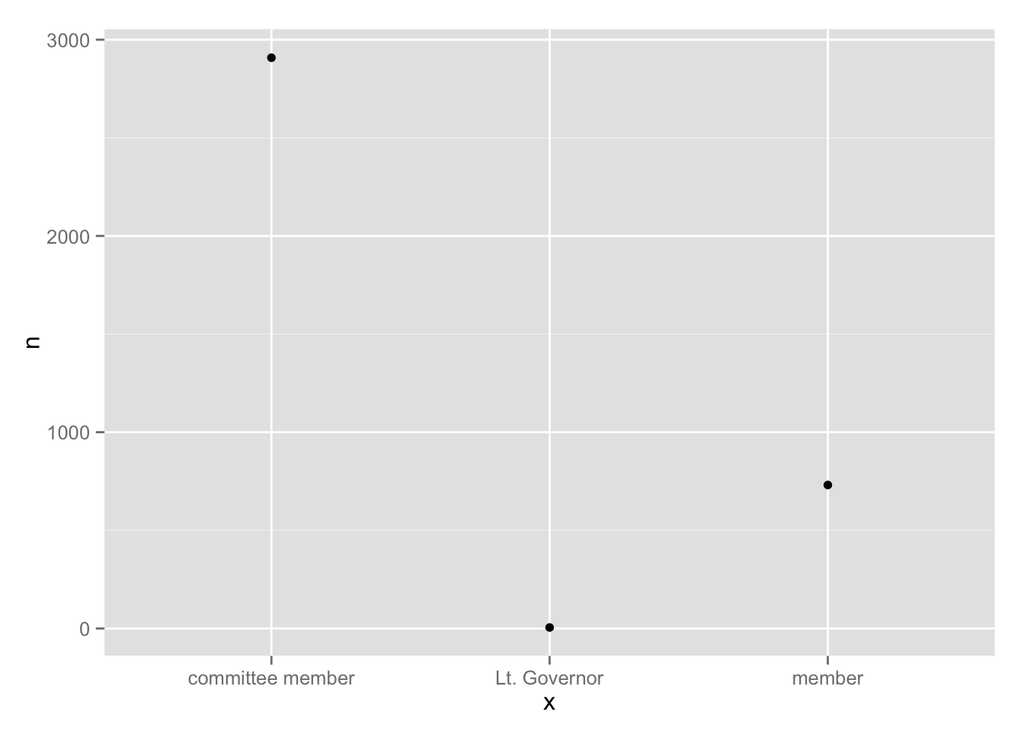

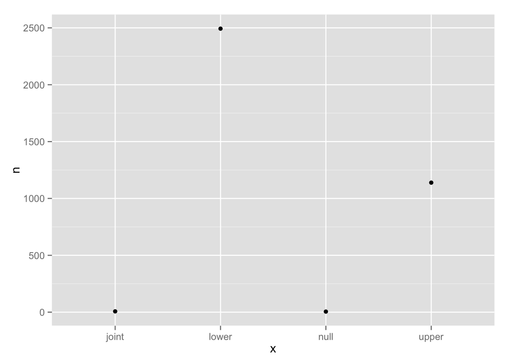

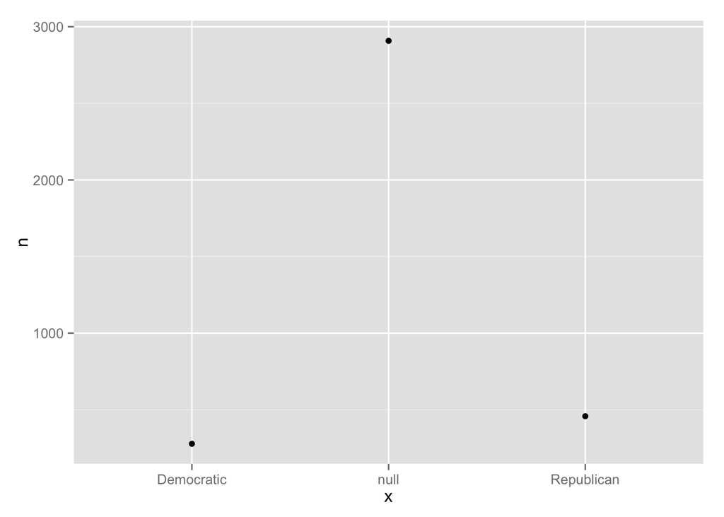

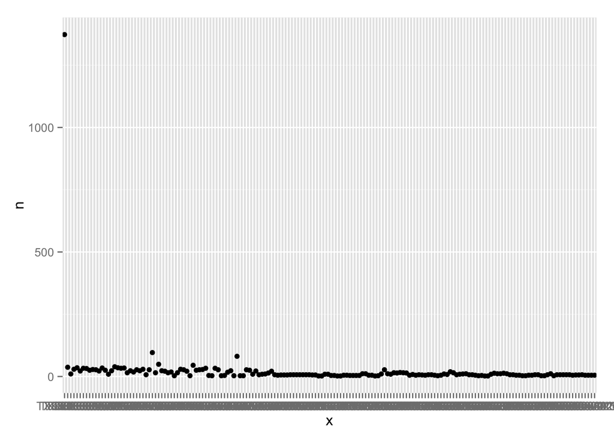

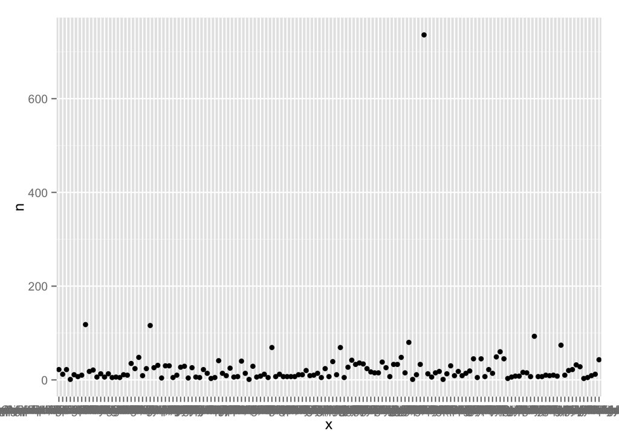

```
## stat_bin: binwidth defaulted to range/30. Use 'binwidth = x' to adjust this.
```

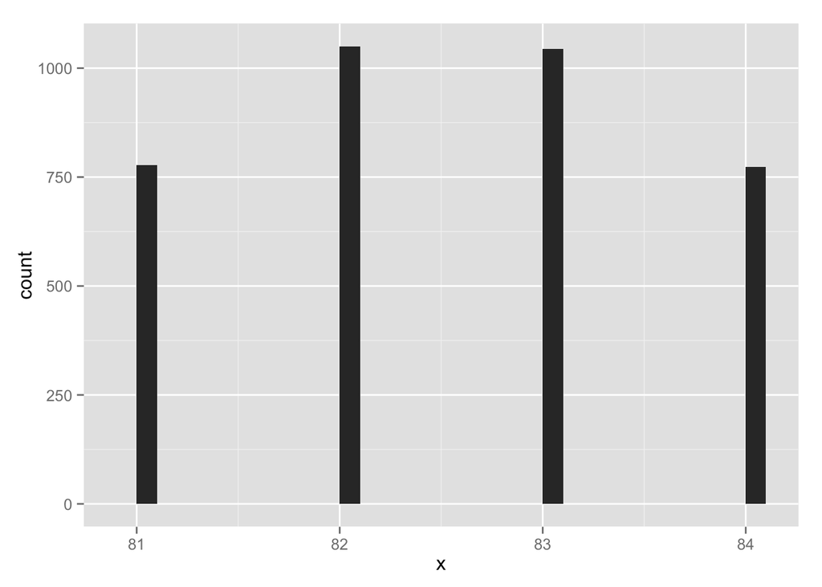

```
## stat_bin: binwidth defaulted to range/30. Use 'binwidth = x' to adjust this.
```

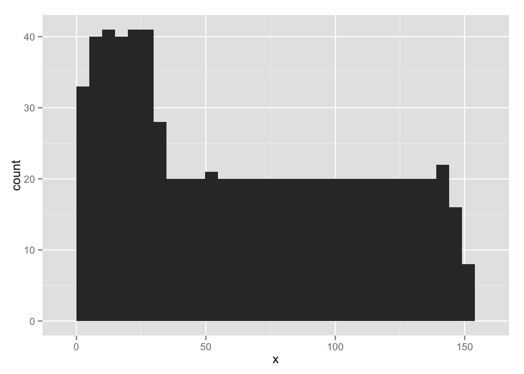

```
## stat_bin: binwidth defaulted to range/30. Use 'binwidth = x' to adjust this.
## stat_bin: binwidth defaulted to range/30. Use 'binwidth = x' to adjust this.
```

```
## stat_bin: binwidth defaulted to range/30. Use 'binwidth = x' to adjust this.
## stat_bin: binwidth defaulted to range/30. Use 'binwidth = x' to adjust this.
```

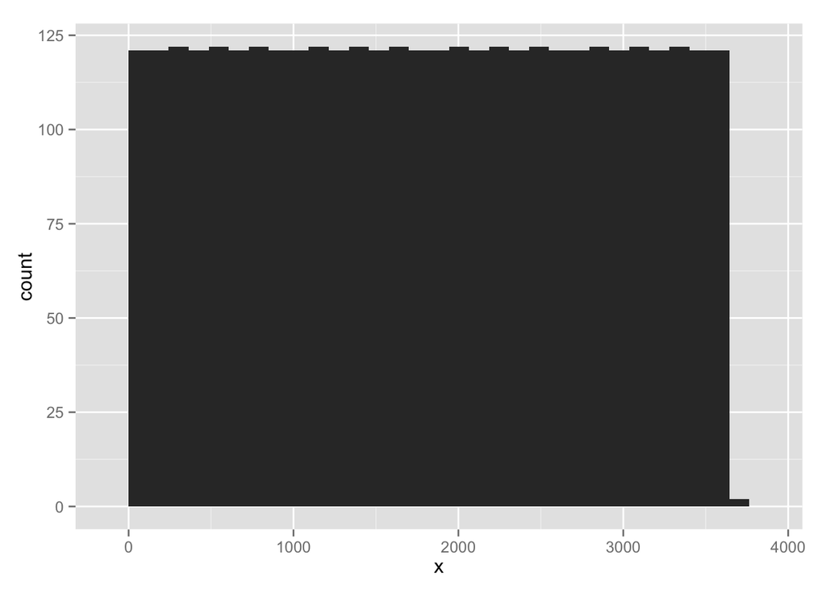

There raw plots are not organized, so the information seem very messy. We use visual formatting for those categorical visualizations to gain the following graphs:

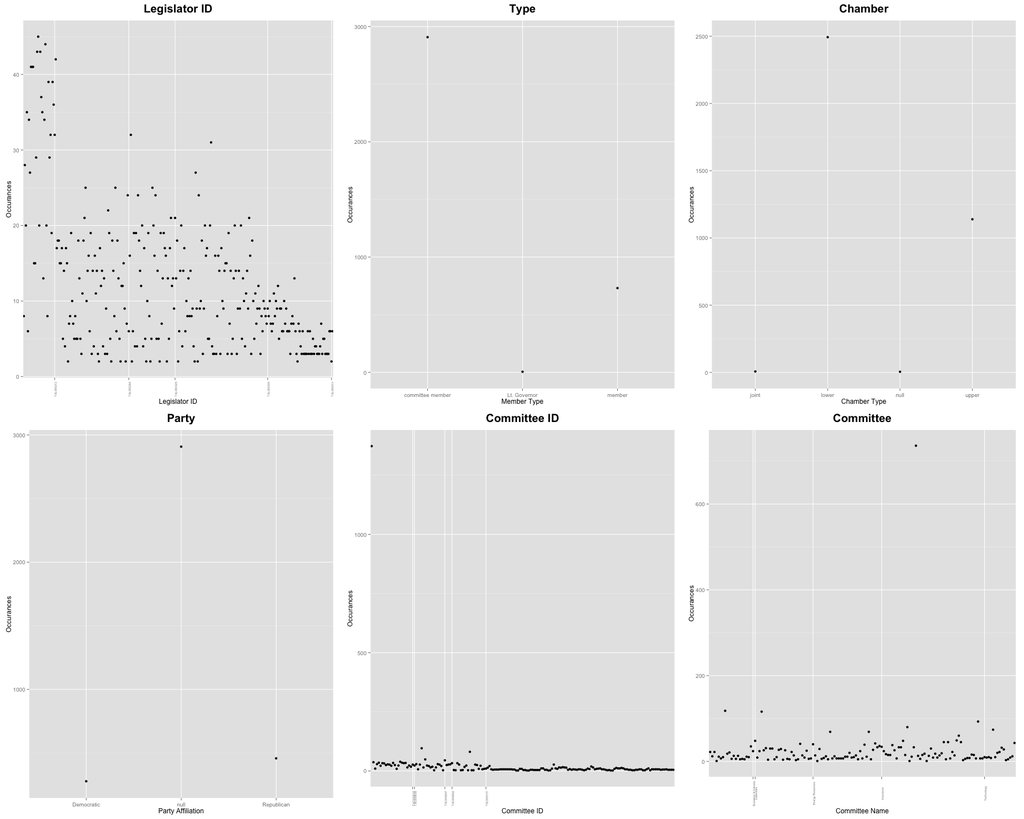

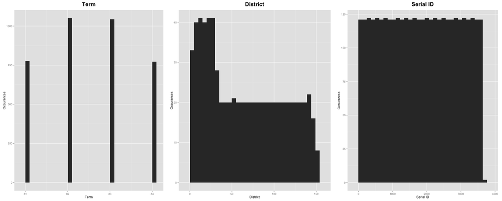